# Приложение: “Проект SQL: отток сотрудников из компании”

Кобзева Ольга, oakobzeva

## Задача

Для переработки я выбрала проект 1 семестра 3 курса про исследование и предсказание оттока сотрудников из некоторой компании. В приложение я буду преобразовывать часть, где по данным сотрудника предсказывается, уйдёт он из компании или нет. Причём приложение будет касаться только молодых сотрудников (как в изначальном проекте), так как это наиболее интересный сегмент.

Такое приложение может быть полезно, во-первых, для руководителей компании. Им может пригодиться предсказание, уйдёт сотрудник из компании или нет, для того чтобы планировать, какое количество персонала набирать, нужно ли что-то менять и прочее. Во-вторых, такое приложение будет полезно также для самих сотрудников. Они смогут видеть, как бы на их месте поступили другие и, возможно, приложение позволит им легче принять решение, уходить из компании или нет. Также это приложение будет полезно другим компаниям, которые на основе данных рассматриваемой компании смогут сделать какие-то выводы для себя. И, наконец, тем, кто интересуется, может быть любопытно проанализировать, при каких условиях молодой сотрудник увольняется.

## Предварительный анализ

В выполненном проекте также были исследованы важности каждой из переменных для построенной модели. Для того чтобы вводимые данные не были слишком длинной анкетой, выбырем самые важные переменные и построим модель по ним, хотя в проекте при построении были использованы все переменные.

```r
#Необходимые пакеты
library(plotly)
library(crosstalk)
library(DBI)
library(ggplot2)
library(partykit)
library(caret)


#Подключимся к базе данных
library(DBI)
con <- dbConnect(ClickHouseHTTP::ClickHouseHTTP(),
                 user='studentminor',
                 password='DataMinorHSE!2023',
                 dbname='employee',
                 host='rc1a-i6ui9dhblsq8rgdo.mdb.yandexcloud.net',
                 port = 8443,
                 https=TRUE,
                 ssl_verifypeer=FALSE)

#Работаем с выбранным сегментом
library(dplyr)
data_young = dbGetQuery(con, "SELECT * FROM profile INNER JOIN portfolio ON profile.EmployeeNumber = portfolio.EmployeeNumber
                  WHERE (Age <= 35 AND YearsAtCompany <= 7)")

data_young = data_young %>% mutate_if(is.character, as.factor)
data_young$Attrition = as.factor(data_young$Attrition)

dbDisconnect(con)

data_young = select(data_young, -EmployeeNumber)

#Немного упростим модель -- построим по меньшему количеству переменных. Выберем самые важные
data_young = select(data_young, Attrition, OverTime, YearsAtCompany, WorkLifeBalance, TotalWorkingYears, NumCompaniesWorked, MaritalStatus, Gender, Education, Age)

#Строим модель -- дерево

set.seed(7777) #Тестовая и обучающая выборка
data_young.ind = createDataPartition(data_young$Attrition, p = 0.75, list = F, times = 1)
data_young.train = data_young[data_young.ind,]
data_young.test = data_young[-data_young.ind,] #Тестовая выборка была нужна для проверки точности -- здесь точность достаточно высокая

set.seed(7777)
treemodel = ctree(Attrition ~ ., data = data_young.train)
#plot(treemodel)

saveRDS(treemodel, file = "treemodel.rds") #Сохраняем модель
```

## Приложение

Общая логика построена следующим образом. Ввести нужно будет данные: возраст, есть ли переработки, образование и так далее. Выводиться будет информация, уйдёт ли сотрудник с такими данными из компании или нет. Вывод реализован в следующей форме: “Attrition:”, а далее 0, если сотрудник не покинет компанию, и 1, если сотрудник уйдёт.

### Интерфейс

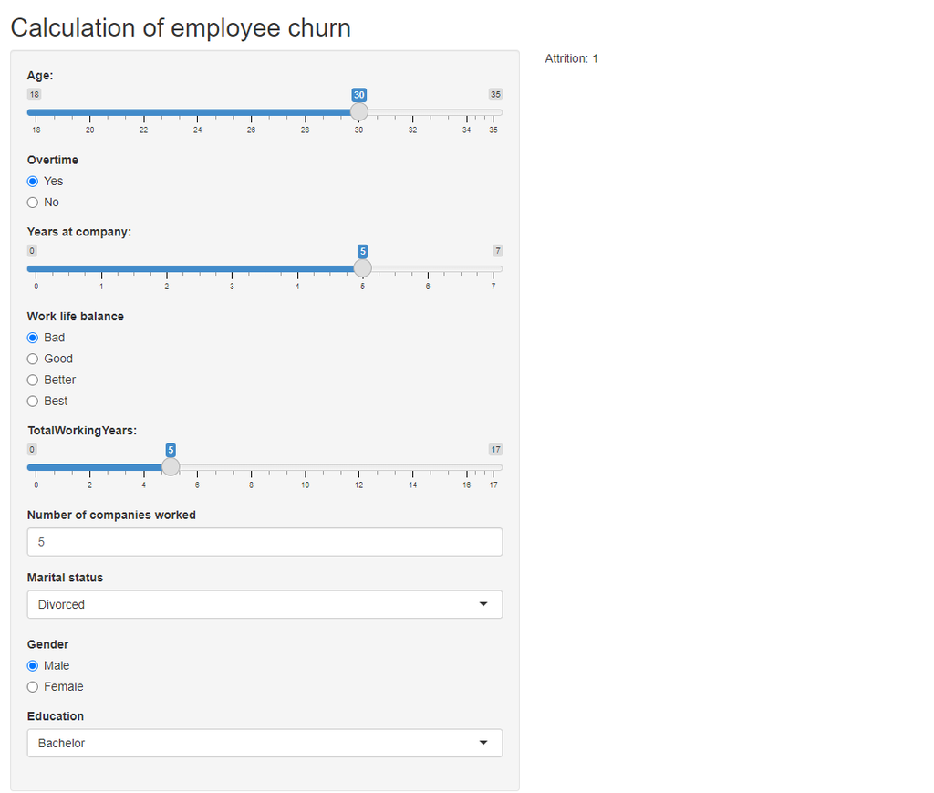

```r
# код интерфейса в неисполняемом чанке

ui <- fluidPage(

    # Application title
    titlePanel("Calculation of employee churn"),

    # Sidebar with a slider input for number of bins
    sidebarLayout(
        sidebarPanel(
          sliderInput("age",
                      "Age:",
                      min = 18,
                      max = 35,
                      value = 30),
          radioButtons("overtime", "Overtime", c("Yes", "No")),

            sliderInput("years",
                        "Years at company:",
                        min = 0,
                        max = 7,
                        value = 5),
            radioButtons("balance", "Work life balance", c("Bad", "Good", "Better", "Best")),
            sliderInput("working",
                        "TotalWorkingYears:",
                        min = 0,
                        max = 17,
                        value = 5),
            numericInput("num", "Number of companies worked", 5, min = 1, max = 10),
            selectInput("marital", "Marital status", c("Divorced", "Single", "Married")),
            radioButtons("sex", "Gender", c("Male", "Female")),
            selectInput("edu", "Education", c("Bachelor", "Below College", "College", "Master"))
        ),


        # Show a plot of the generated distribution
        mainPanel(
          textOutput("ans")

        )
    )
)
```

### Сервер

```r
# код сервера в неисполняемом чанке

server <- function(input, output) {

    output$ans <- renderText({
      treemodel = readRDS("treemodel.rds")
      info = c(input$overtime, input$years, input$balance, input$working, input$num,
               input$marital, input$sex, input$edu, input$age)
      info = data.frame(OverTime = as.factor(input$overtime), YearsAtCompany = as.integer(input$years), WorkLifeBalance = as.factor(input$balance),
                        TotalWorkingYears = as.integer(input$working), NumCompaniesWorked = as.integer(input$num), MaritalStatus = as.factor(input$marital),
                        Gender = as.factor(input$sex), Education = as.factor(input$edu), Age = as.integer(input$age))
      p = predict(treemodel, info)

      str = as.character(as.integer(p) - 1)
      strr = paste("Attrition:", str)
      strr

    })
}
```

## Ссылка

```r
#https://olgakobzeva.shinyapps.io/Mainor_hw/
```